# EDIFF :: Process powder electron diffraction pattern

- **Sample**:
  - Au nanoislands
  - Local backup: `D:\DATA.SH\STEMDIFF\X_TESTING\1AU`
- **Input**:
  - CIF file for calculation of *theoretical* PXRD diffraction pattern.
  - Image file containing *experimental* 2D powder electron diffraction pattern.
- **Output**:
  - Several plots and text files in current dir = the directory with this notebook.
  - The final plot = comparison of experimental ED and theoretical PXRD diffractogram.

# 1. Initialization

- **Automatic step**; no user input necessary.

```python
# (a) Import modules
import numpy as np
import matplotlib.pyplot as plt
import ediff.io, ediff.radial, ediff.background, ediff.pxrd
```

```python
# Initialize plotting in Jupyter
# (the following cell is necessary to set plot parameters reproducibly
# (a correction of a Jupyter bug - the 1st plot tends to use Jupyter defaults
ediff.io.set_plot_parameters(); plt.show()
```

# 2. Theoretical PXRD

- **Semi-automatic step**; you define I/O files in (a) and adjust parameters in (c).
- We start with theoretical PXRD to have some idea how the data should look like.
- To calculate the pattern, a CIF file (Crystallographic Information File) is needed.
- CIF files for known crystal structures can be downloaded from crystallographic databases.
- Good sources of CIF files = Crystallographic Open Database: http://www.crystallography.net/cod

```python
# (a) Define input and output files
# (CIF_FILE = crystal information file, input text file from www
# (XRD_FILE = output file, calculated below, intensity = f(diff.angle/vector)
CIF_FILE = r'./CIF/au_9008463.cif'
XRD_FILE = r'./xrd_au.txt'
```

```python
# (b) Adjust plot parameters - for PXRD plots
ediff.io.set_plot_parameters(size=(10,5), dpi=120, fontsize=8)
```

```python
# (c) Prepare parameters for calculation
# (We simulate a fictive PXRD experiment on the crystal from CIF_FILE.
# (XTAL = crystal parameters
# (EPAR = experimental parameters
# (PPAR = plotting parameters = data for graphs
XTAL = ediff.pxrd.Crystal(structure=CIF_FILE, temp_factors=0.8)
EPAR = ediff.pxrd.Experiment(wavelength=0.71, two_theta_range=(2,140))
PPAR = ediff.pxrd.PlotParameters(x_axis='q', xlim=(1,10))
```

```python
# (d) Calculate the PXRD diffractogram
PXRD = ediff.pxrd.PXRDcalculation(XTAL, EPAR, PPAR, peak_profile_sigma=0.1)
```

```python
# (e) Save the PXRD calculation results
PXRD.save_diffractogram(XRD_FILE)
PXRD.save_diffractions(XRD_FILE + '.diff')
```

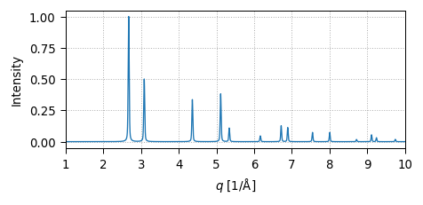

```python
# (f) Plot the PXRD calculation results
PXRD.plot_diffractogram(XRD_FILE + '.png')
```

# 3. Experimental ED

- Section 3.1: Read experimental 2D powder electron diffraction pattern.
- Section 3.2: Convert the 2D-pattern to radially averged 1D profile.
- Section 3.3: Subtract backround from the 1D profile.
- Section 3.4: Calibrate 1D profile (convert distances in pixels to diffraction vectors q in 1/A).

## 3.1. Show 2D diffractogram

- **Automatic step**; you just define input file = 2D-diffractogram in (a).

```python
# (a) Define input file
# (input = 2D-powder diffractogram in the form of image
ED_DIFFRACTOGRAM = r'./SDIFF/sum_fd_16bit.png'
```

```python
# (b) Adjust plot parameters - for 2D diffractograms
ediff.io.set_plot_parameters(size=(9,9), dpi=100, fontsize=10)
```

```python
# (c) Read 2D-diffractogram
# (read image to 2D-numpy array
diffractogram = ediff.io.read_image(ED_DIFFRACTOGRAM, itype='16bit')
```

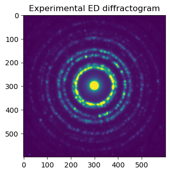

```python
# (d) Show 2D-diffractogram
plt.title('Experimental ED diffractogram')
plt.imshow(diffractogram, vmax=150)
plt.tight_layout()
plt.show()
```

## 3.2. Convert to 1D profile

- **Automatic step**; you just define output file = 1D-profile in (a).

```python
# (a) Define output file
# (TXT-file containing radially averaged ED profile
ED_FILE1 = r'.\ed1_raw.txt'
```

```python
# (b) Adjust plot parameters - for 1D-profiles
ediff.io.set_plot_parameters(size=(10,5), dpi=120, fontsize=8)
```

```python
# (c) Convert 2D-diffractogram to 1D-radial distribution
profile = ediff.radial.calc_radial_distribution(diffractogram)
```

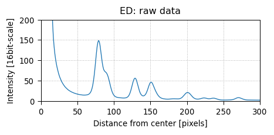

```python
# (d) Plot radial distribution
plt.title('ED: raw data')
plt.plot(profile[0],profile[1])
plt.xlabel('Distance from center [pixels]')
plt.ylabel('Intensity [16bit-scale]')
plt.xlim(0,300)
plt.ylim(0,200)
plt.grid()
plt.tight_layout()
plt.show()
```

```python
# (e) Save radial distribution to file
np.savetxt(ED_FILE1, np.transpose(profile),
           fmt=['%4d','%8.2f'], header='Columns: Pixels, Intensity')
```

## 3.3. Subtract background

- **Interactive step:**
  - Define output file in (a).
  - Then a new window will be opened after running (d).
  - In the new window, define background with mouse and keyboard.
  - Basic instructions are below, more info when pressing 0 in the newly-opened window.

```python
# (a) Define output file for saving the data
ED_FILE2 = 'ed2_bcorr.txt'
```

```python
# (b) Switch to interactive plots
# (we need fully interactive plots in external window
%matplotlib qt
```

```python
# (c) Prepare interactive plot
DATA = ediff.background.InputData(
    ED_FILE1, usecols=[0,1], unpack=True)
PPAR = ediff.background.PlotParams(
    'Pixels','Intensity', xlim=[0,300], ylim=[0,180])
IPLOT = ediff.background.InteractivePlot(
    DATA, PPAR, ED_FILE2, CLI=False)
```

```python
# (d) Run the interactive plot
# * A new window entitled {Background definition} will be opened!
# * In the newly-opened window, define background with mouse and keyboard.
# * Instructions: Press 0 in the new window - brief help will be printed below.
# (Note1: The keyboard shortcuts (0,1,2...) work only within the new window.
# (Note2: Instructions and text messages are printed as output of this cell.
# (Note2: The plot is not shown in this notebook, output is saved in ED_FILE2.
IPLOT.run()
```

```
Activate interactive plot window and press:
0 = to print brief help in notebook/console window
1 = to draw background point at current mouse position
2 = to delete background point...
---
```

```python
# (e) Switch back to standard, non-interative plots
%matplotlib inline
```

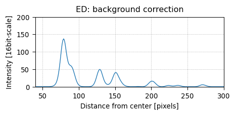

```python
# (f) Plot the file with subtracted background
# -----
# Reset plot parameters - interactive bkg-correction might have change them
ediff.io.set_plot_parameters(size=(10,5), dpi=120, fontsize=8)
# Read the saved profile with subtracted background
profile = np.loadtxt(ED_FILE2, unpack=True)
# Plot the profile with subtracted background
plt.title('ED: background correction')
plt.plot(profile[0],profile[2])
plt.xlabel('Distance from center [pixels]')
plt.ylabel('Intensity [16bit-scale]')
plt.xlim(40,300)
plt.ylim(0,200)
plt.grid()
plt.tight_layout()
plt.show()
```

## 3.4. Calibrate

- **Automatic step**; if everything works as expected, no user input needed.

```python
# Calibrate ED pattern on the bases of PXRD pattern
# (Compare some strong peak in files FILE2 and PXRD_FILE
# (Calibrate the ED pattern based on the rule-of-three => see below
```

```python
# (a) Reload ED- and XRD-profiles
ed  = np.loadtxt(ED_FILE2, unpack=True)
xrd = np.loadtxt(XRD_FILE, unpack=True)
```

```python
# (b) Find position of maximal peak in ED
max_ed  = float(ed[0,(ed[2]==np.max(ed[2]))])
max_xrd = float(xrd[2,(xrd[3]==np.max(xrd[3]))])
print(f'Position of max.peak in ED-profile: {max_ed:6.4f} in d [pixel]')
print(f'Position of max.peak in XRD-profile: {max_xrd:6.4f} in q [1/A]')
```

```
Position of max.peak in ED-profile: 79.0000 in d [pixel]
Position of max.peak in XRD-profile: 2.6680 in q [1/A]
```

```python
# (c) Calculate calibration constant
# (the constant converts d[pixels] to q[1/A]
calibration_constant = max_xrd/max_ed
print(f'Calibration constant: {calibration_constant:.6f}')
```

```
Calibration constant: 0.033772
```

```python
# (d) Calibrate and normalize ED-profile
ed[0] = ed[0] * calibration_constant
ed[1] = ed[1]/np.max(ed[1])
ed[2] = ed[2]/np.max(ed[2])
```

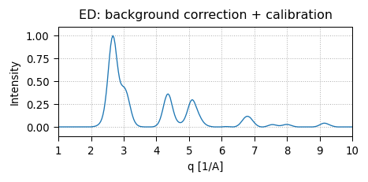

```python
# (e) Plot the calibrated ED profile with subtracted background
plt.title('ED: background correction + calibration')
plt.plot(ed[0],ed[2])
plt.xlabel('q [1/A]')
plt.ylabel('Intensity')
plt.xlim(1,10)
plt.ylim(-0.1,1.1)
plt.grid()
plt.tight_layout()
plt.show()
```

```python
# (f) This was preliminary calibration.
# => now we have {ed} and {xrd} arrays with ED and XRD profiles, respectively
# => the fine-tuning and saving the final results is made in the next section
```

# 4. Final comparison of ED and PXRD

- **Semi-automatic step**:
  - Define final output file in (a).
  - Define fine_tuning constant in (b) - start with the value of 1.
  - Plot the result in (c) and see if the peak overlap - if not adjust constant in (b), re-run (c) ...
  - Once the graph in (c) is Ok, run cell (d) to save final ED profile as text for further processing or plotting.

```python
# (a) Define name for the final ED-profile
# (this name will be used for final TXT-file
ED_FILE3 = 'ed3_final.txt'
```

```python
# (b) Set fine-tuning constant
# (the constant should be close to 1
# (adjust manually so that ED and PXRD peaks
# (in the following grapha overlapped perfectly
fine_tuning = 1.000
```

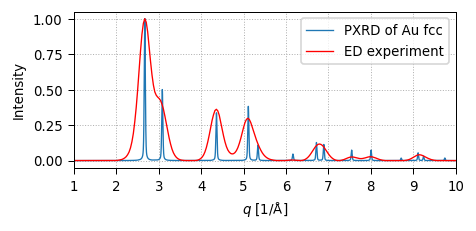

```python
# (c) Plot and save final result graph
plt.plot(xrd[2], xrd[3], label=r'PXRD of Au fcc')
plt.plot(ed[0]*fine_tuning,ed[2], color='red', label='ED experiment')
plt.xlim(1,10)
plt.xlabel('$q$ [1/\u212B]')
plt.ylabel('Intensity')
plt.legend()
plt.grid()
plt.tight_layout()
plt.savefig(ED_FILE3+'.png', dpi=300)
plt.show()
```

```python
# (d) Save final fine-tuned ED profile for possible further processing
np.savetxt(
    ED_FILE3, np.transpose(ed),
    fmt=['%8.3f','%8.3f', '%8.3f'],
    header='Columns: q[1/A], IntensityRaw, IntensityFin')
```

```python
# END OF PROGRAM.
# * Final output is in ED_FILE3 (txt and png).
# * Additional ouputs in XRD_FILE, ED_FILE1, and ED_FILE2 (txt and png).
```